# Introduction to probability and statistics project task

## Preface

School year 2019/20  
Name and surname:`Ardit Nela`  
Registration number:`63190375`  
Dataset:`podatki_zavor.csv`

### Declaration of authorship

I declare that I have completed the assignment independently.

## Initialization and description of data

Initially, we import all the required libraries for our project:

```python
import matplotlib.pyplot as plt
import numpy as np
import seaborn as sns
import pandas as pd
from scipy.stats import pearsonr, ttest_ind, norm
from scipy import stats


%matplotlib inline
```

Secondly, we must load and store the data from our dataset. Our data pool is comprised of 62 samples in total, where each sample (row) contains two numbers as information. The first number is a numerical value that represents the speed of a specific car in kilometers per hour; whereas the second one represents the breaking distance, or path that that vehicle has to traverse in meters.

```python
data = pd.read_csv('C:\\Users\\Ardit\\Desktop\\OVS seminar\\podatki_zavor.csv', engine='python')
hitrost = np.array([x for x in data['hitrost']])
pot = np.array([x for x in data['pot']])

poti_sqrt = np.array([np.sqrt(x) for x in data['pot']])

print("\nOverview of the data:\n")
print(data)
```

```
Overview of the data:

    hitrost    pot
0         6   1.22
1         8   0.61
2         8   1.22
3         8   2.44
4         8   2.44
..      ...    ...
57       56  32.61
58       58  24.08
59       63  42.06
60       64  33.53
61       64  40.84

[62 rows x 2 columns]
```

## Research hypothesis

Our main goal is to determine whether there exists a linear (functional) dependency between the speed and the path of the given cars. We must also take into account the values of the path if their squared roots were to be considered.

```python
pot_sqrt = np.array([np.sqrt(x) for x in pot])
```

## Descriptive statistics

### Speed of movement

```python
print("Descriptive information regarding speed\n")
pd.DataFrame(hitrost).describe()
```

```
Descriptive information regarding speed
```

|  | 0 |
| --- | --- |
| count | 62.000000 |
| mean | 30.387097 |
| std | 16.013677 |
| min | 6.000000 |
| 25% | 16.000000 |
| 50% | 28.000000 |
| 75% | 42.750000 |
| max | 64.000000 |

Shown in the table above is some basic illustrative information for speed. There are a *total* of **62** speed values, their *mean* is approximately **30.387097**, the *standard deviation* approximates to **16.013677**. We can also see the *maximum* and *minimum* values, which are **64**km/h and **6**km/h respectively.

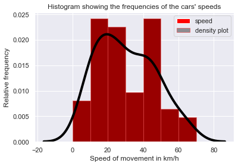

```python
sns.set()

plt.hist(hitrost, color = 'red', density= True, bins = [0, 10, 20, 30, 40, 50, 60, 70])
plt.title("Histogram showing the frequencies of the cars' speeds")
plt.xlabel("Speed of movement in km/h")
plt.ylabel("Relative frequency")

sns.distplot(hitrost, hist=True, kde=True,
             bins = [0, 10, 20, 30, 40, 50, 60, 70], color = 'black',
             hist_kws={'edgecolor':'red'},
             kde_kws={'linewidth': 4})
labels = ["speed","density plot"]
plt.legend(labels)
```

It is apparent from the graph that *most* vehicles have speeds between **[10,30]** and **[40,50]**

### Path (breaking distance)

```python
print("Descriptive information regarding path\n")
pd.DataFrame(pot).describe()
```

```
Descriptive information regarding path
```

|  | 0 |
| --- | --- |
| count | 62.000000 |
| mean | 11.980323 |
| std | 10.172463 |
| min | 0.610000 |
| 25% | 4.037500 |
| 50% | 8.990000 |
| 75% | 17.295000 |
| max | 42.060000 |

Shown in the table above is some basic illustrative information for path. There are a *total* of **62** speed values, their *mean* is approximately **11.980323**, the *standard deviation* approximates to **10.172463**. We can also see the *maximum* and *minimum* values, which are **42.06**m and **0.61**m respectively.

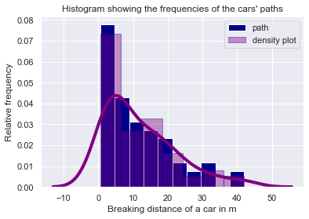

```python
sns.set()

plt.hist(pot, color = 'darkblue', density= True)
plt.title("Histogram showing the frequencies of the cars' paths")
plt.xlabel("Breaking distance of a car in m")
plt.ylabel("Relative frequency")

sns.distplot(pot, hist=True, kde=True, color = 'purple', hist_kws={'edgecolor':'darkblue'},
             kde_kws={'linewidth': 4})
labels = ["path","density plot"]
plt.legend(labels)
```

It is visible from the graph that the path is unevenly distributed (*right-skewed* assymetrical distribution)

## The regression model and its graphical representation (scatter plot)

```
Pearson's correlation coefficient is 0.9356. It shows us that there is a linear correlation between the two variables.
```

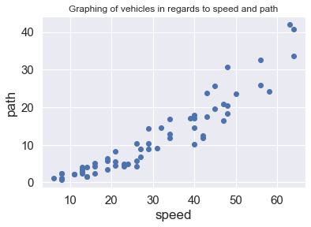

```python
sns.set()

plt.xlabel("speed", fontsize=17)
plt.ylabel("path", fontsize=17)
plt.xticks(fontsize=15)
plt.yticks(fontsize=15)
plt.title("Graphing of vehicles in regards to speed and path")
plt.plot(hitrost, pot,"o")

r = pearsonr(hitrost, pot)
print(f"Pearson's correlation coefficient is{r[0]: .4f}. It shows us that there is a linear correlation between the two variables.")
```

The formula we use to perform linear regression is:  
$Y = mX + a$  
where:  
*Y* → path  
*m* → the slope of our line. It is calculated as such: $r\frac{S_{y}}{S_{x}}$  
*X* → the speed of movement  
*a* → $mean(y) - m * mean(x)$

The scatter plot clearly shows that a linear regression model with the raw data of path will prove to be innacurate. There are outliers present and they have an *undue influence* on the regression line. In order to fix this, we may take the square root of the path values.

```
Path and sqrt(path) comparison
```

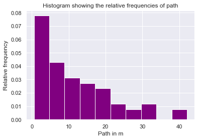

```python
print("Path and sqrt(path) comparison\n")

sns.set()
plt.hist(pot, color = 'purple', density= True)
plt.xlabel("Path in m")
plt.ylabel("Relative frequency")
plt.title("Histogram showing the relative frequencies of path")
```

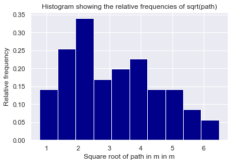

```python
sns.set()

plt.hist(pot_sqrt, color = 'darkblue', density= True)
plt.xlabel("Square root of path in m in m")
plt.ylabel("Relative frequency")
plt.title("Histogram showing the relative frequencies of sqrt(path)")
```

```
Pearson's correlation coefficient is 0.9615. It shows us that not only is there a linear correlation between the two variables, but it is also stronger and more effective.
```

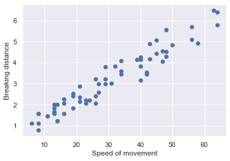

```python
sns.set()

plt.plot(hitrost, pot_sqrt, "o")
plt.xlabel("Speed of movement")
plt.ylabel("Breaking distance")

r1 = pearsonr(hitrost, pot_sqrt)[0]
print(f"Pearson's correlation coefficient is{r1: .4f}. It shows us that not only is there a linear correlation between"
" the two variables, but it is also stronger and more effective.")
```

Now, we will find the linear regression using the same formula as before. We are able to find the linear regression of both X and Y variables and it will go as follows:  
*First regression:* $Y = m_{1}X + a_{1}$  
*Second regression:* $X = m_{2}Y + a_{2}$  
where:  
*Y* → square root of the breaking distance  
*X* → speed of movement

```python
meanHitrost = np.mean(hitrost)
meanSqrtP = np.mean(pot_sqrt)
```

```python
C_hitr2 = sum((hitrost - meanHitrost)**2)
C_hitr_pot = sum((hitrost - meanHitrost) * (pot_sqrt - meanSqrtP))

b1 = C_hitr_pot/C_hitr2
a1 = meanSqrtP - b1*meanHitrost

print(f"The first line of the regression line is: Y = {b1: .4f}*X +{a1: .4f}")
```

```
The first line of the regression line is: Y =  0.0866*X + 0.5200
```

```python
C_poti2 = sum((pot_sqrt - meanSqrtP)**2)
sx2 = np.std(hitrost)**2
sy2 = np.std(pot_sqrt)**2

b2 = r1 * np.sqrt(sx2 / sy2)
a2 = meanHitrost - b2*meanSqrtP

print(f"The second regression line is: X ={b2 : .4f}*Y{a2: .4f}")
```

```
The second regression line is: X = 10.6755*Y-3.2592
```

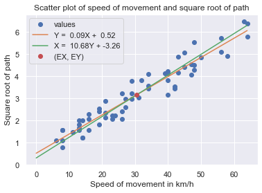

```python
sns.set

h0 = np.array([0,64])
plt.plot(hitrost, pot_sqrt, 'o')
plt.plot(h0, b1*h0+a1)
plt.plot(h0, (h0 - a2)/b2)

plt.plot(meanHitrost, meanSqrtP, 'ro')
plt.xlabel("Speed of movement in km/h")
plt.ylabel("Square root of path")
plt.title("Scatter plot of speed of movement and square root of path")
plt.legend(['values', f"Y = {b1: .2f}X + {a1: .2f}",  f"X = {b2: .2f}Y + {a2: .2f}", "(EX, EY)"], loc = 0)
```

```
The mean squared deviation is: 0.1595
```

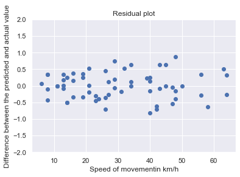

```python
res = [yi - (a1 + b1*xi) for xi, yi in zip(hitrost, pot_sqrt)]
std_res = np.std(res)
res_squared = [x**2 for x in res]

plt.scatter(hitrost, res)
plt.ylim(-2, 2)
plt.title("Residual plot")
plt.ylabel("Difference between the predicted and actual value")
plt.xlabel("Speed of movementin km/h")

mse = sum(res_squared)/(60)
print(f"The mean squared deviation is:{mse: .4f}")
```

```python
print(f"The standard deviation of the errors  in {std_res : .3f}")

var_res = sum([ei**2 for ei in res])/(len(res)-2)
print(f"The variance of errors is constant and equal to {var_res: .3f}")
```

```
The standard deviation of the errors  in  0.393
The variance of errors is constant and equal to  0.160
```

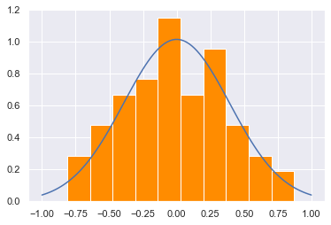

```python
plt.hist(res, density=True, color = "darkorange")
domain = np.linspace(-1, 1, 100)
plt.plot(domain, norm.pdf(domain ,0, std_res))
```

## Testing our linear model

At first, we need to figure out whether we have a correlation between our X and Y values. This can be done by checking if the Null Hypothesis (H0) is valid. We may use a t-test to accomplish this. Let us assume that $\alpha = 0.05$.

```python
n = len(hitrost)
alpha = 0.05
cv = stats.t.ppf(1.0 - alpha/2, n - 2)

T = (b1 / std_res) * np.sqrt((n - 1) * np.std(hitrost))
t_stat, p_val = ttest_ind(hitrost, pot_sqrt)

print(f"The t-statistic:{t_stat: .4f}, the critical value(cv):{cv: .4f}, and the test: {T: .4f}")
```

```
The t-statistic: 13.3378, the critical value(cv): 2.0003, and the test:  6.8610
```

```python
correlation_matrix = np.corrcoef(hitrost, pot_sqrt)
correlation_xy = correlation_matrix[0,1]
r_squared = correlation_xy**2

print(f"Coefficient of determination:{r_squared: .4f}")
```

```
Coefficient of determination: 0.9246
```

As we can clearly see, the *coefficient of determination* is high (close to 1); meaning we can predict data with *relatively high accuracy*.

## Confidence and Prediction Intervals

### Slope and Intercept confidence intervals

Let us assume that $\beta = 0.95$.

```python
beta = 0.95
```

```python
c = stats.t.ppf((1.0 + beta)/2, n - 2)
delta = c * std_res / (np.sqrt(n-1)*np.std(hitrost))
print(f"The confidence interval for the slope is ({b1-delta : .2f}, {b1+delta : .2f} )")
```

```
The confidence interval for the slope is ( 0.08,  0.09 )
```

```python
delta = c * std_res * np.sqrt(1/n + meanHitrost**2.0 / ((n-1)* np.std(hitrost)**2.0))
print(f"The confidence interval for the intercept is ({a1-delta : .2f}, {a1+delta : .2f} )")
```

```
The confidence interval for the intercept is ( 0.30,  0.74 )
```

### Prediction interval

```python
def getDelta(x0):
    return c * std_res * np.sqrt(1 + 1/n + (x0 - meanHitrost)**2 / ((n-1)* np.std(hitrost)**2))
```

We can establish a prediction interval using the confidence interval.

```python
arr = [30, 60, 15]
for x0 in arr:
    print(f"When the car moves with speed of {x0}km/h the predicted breaking distance is {(b1*x0+a1)**2 : .2f} +/-{getDelta(x0)**2 : .2f}")
```

```
When the car moves with speed of 30km/h the predicted breaking distance is  9.72 +/- 0.63
When the car moves with speed of 60km/h the predicted breaking distance is  32.68 +/- 0.66
When the car moves with speed of 15km/h the predicted breaking distance is  3.31 +/- 0.64
```